# DSC450-T301 - Project 1: Project Draft Group Assignment (Milestone 2)

**Professor**: Fadi Alsaleem  
**@Copyright**: BELLEVUE.edu  
**OS**: Windows 11 x64  
**Processor**: i9-13900  
**GPU**: NVIDIA GeForce RTX 3060  
**IDE**: DataSpell 2025.2  
**Interpreter**: Python 3.11  
**Libraries Managed by**: Miniforge3

**Team Roles**:

1. **Data Wrangler**: Andres Melendez  
   **Responsibilities**:
- Data acquisition
- Cleaning
- Transformation
- Quality Assessment
2. **Data Scientist**: Delilah Slabaugh & Carlos Escamilla  
   **Responsibilities**:
- Data exploration
- Model Development
- Analysis
- Recommendations
3. **Data Visualizer/Presenter**: Tyler Heflin  
   **Responsibilities**:
- Create visualizations
- Presentation Design
- Storytelling

**Version**:

- 1.0.0 - 2025.06.09 Week2 - Milestone 1: Proposal and Data Selection Group Assignment
- 1.0.1 - 2025.06.16 Week3 - Milestone 2: Project Draft Group Assignment
- 1.0.1 - 2025.06.23 Week4 - Milestone 3: Team Evaluation

**Resources**:

- [NOAA Global Monitoring Laboratory](https://gml.noaa.gov/ccgg/trends/data.html)
- [NASA GISS Surface Temperature Analysis](https://data.giss.nasa.gov/gistemp/)
- [NOAA PSL - Global Sea Level](https://psl.noaa.gov/data/timeseries/month/SEALEVEL/)

# DATA WRANGLER

**Author**:  
Andres Melendez

### Climate Data Summary Script

This script loads and summarizes three key climate datasets:

1. Atmospheric CO2 concentration (Mauna Loa, NOAA)
2. Global mean sea level rise (NASA PO.DAAC)
3. Global surface temperature anomalies (NASA GISTEMP)

```python
import pandas as pd
import xarray as xr

# --- Load Mauna Loa CO₂ Monthly Mean Data ---
# Source: NOAA ESRL (Keeling Curve), from 1958 to present
# Columns include raw and deseasonalized CO₂ in ppm
co2 = pd.read_csv("Data/co2_mm_mlo.csv", comment='#', header=None)
co2.columns = [
    "year", "month", "decimal date",
    "average", "deseasonalized", "ndays",
    "sdev", "unc"
]

# --- Load Global Sea Level Rise Data ---
# Source: NASA PO.DAAC
# Contains monthly sea level estimates based on altimetry and tide gauge data
sealevel = pd.read_csv("Data/sealevel.podaac.csv", comment='#')

# --- Load NASA GISTEMP Global Temperature Anomalies ---
# Source: NASA Goddard Institute for Space Studies (GISS)
# Global surface temperature anomaly averaged over land + ocean (monthly)
gistemp_ds = xr.open_dataset("Data/gistemp250_GHCNv4.nc")
gistemp_temp = gistemp_ds['tempanomaly'].mean(dim=['lat', 'lon']).to_series()

# --- Summarize Data ---
summary = {
    "CO2 Data Head": co2.head(),
    "Sea Level Data Head": sealevel.head(),
    "GISTEMP Time Range": (gistemp_temp.index.min(), gistemp_temp.index.max())
}

# Display dictionary of dataset samples and time range
summary
```

```
{'CO2 Data Head':    year  month  decimal date  average  deseasonalized  ndays   sdev    unc
 0  year  month  decimal date  average  deseasonalized  ndays   sdev    unc
 1  1958      3     1958.2027   315.71          314.44     -1  -9.99  -0.99
 2  1958      4     1958.2877   317.45          315.16     -1  -9.99  -0.99
 3  1958      5     1958.3699   317.51          314.69     -1  -9.99  -0.99
 4  1958      6     1958.4548   317.27          315.15     -1  -9.99  -0.99,
 'Sea Level Data Head':          Date  \
 0  1900-01-01
 1  1900-02-01
 2  1900-03-01
 3  1900-04-01
 4  1900-05-01

     1900-2018  missing value -999 https://psl.noaa.gov/data/timeseries/month/
 0                                            -79.554
 1                                            -79.554
 2                                            -79.554
 3                                            -79.554
 4                                            -79.554                           ,
 'GISTEMP Time Range': (Timestamp('1880-01-15 00:00:00'),
  Timestamp('2025-04-15 00:00:00'))}
```

```python
# EDA: gistemp250_GHCNv4.nc
gistemp_ds
```

```
<xarray.Dataset> Size: 113MB
Dimensions:      (lat: 90, lon: 180, time: 1744, nv: 2)
Coordinates:
  * lat          (lat) float32 360B -89.0 -87.0 -85.0 -83.0 ... 85.0 87.0 89.0
  * lon          (lon) float32 720B -179.0 -177.0 -175.0 ... 175.0 177.0 179.0
  * time         (time) datetime64[ns] 14kB 1880-01-15 1880-02-15 ... 2025-04-15
Dimensions without coordinates: nv
Data variables:
    time_bnds    (time, nv) datetime64[ns] 28kB ...
    tempanomaly  (time, lat, lon) float32 113MB nan nan nan nan ... nan nan nan
Attributes:
    title:        GISTEMP Surface Temperature Analysis
    institution:  NASA Goddard Institute for Space Studies
    source:       http://data.giss.nasa.gov/gistemp/
    Conventions:  CF-1.6
    history:      Created 2025-05-07 04:25:24 by SBBX_to_nc 2.0 - ILAND=250, ...
```

This code loads and summarizes three climate datasets:

```python
# Read more lines to find the exact line number where actual column headers and data begin
with open("Data/co2_mm_mlo.csv", "r") as file:
    raw_lines = [next(file) for _ in range(60)]

raw_lines
```

```
['# --------------------------------------------------------------------\n',
 '# USE OF NOAA GML DATA\n',
 '#\n',
 '# These data are made freely available to the public and the scientific\n',
 '# community in the belief that their wide dissemination will lead to\n',
 '# greater understanding and new scientific insights. To ensure that GML\n',
 '# receives fair credit for their work please include relevant citation\n',
 '# text in publications. We encourage users to contact the data providers,\n',
 '# who can provide detailed information about the measurements and\n',
 '# scientific insight.  In cases where the data are central to a\n',
 '# publication, coauthorship for data providers may be appropriate.\n',
 '#\n',
 '#\n',
 '#\n',
 '# Contact:  Xin Lan (xin.lan@noaa.gov)\n',
 '#\n',
 '# File Creation: Thu Jun  5 03:55:22 2025\n',
 '#\n',
 '#\n',
 '# --------------------------------------------------------------------\n',
 '#\n',
 '#\n',
 '# See gml.noaa.gov/ccgg/trends/ for additional details.\n',
 '#\n',
 '# Data from March 1958 through April 1974 have been obtained by C. David Keeling\n',
 '# of the Scripps Institution of Oceanography (SIO) and were obtained from the\n',
 '# Scripps website (scrippsco2.ucsd.edu).\n',
 '# Monthly mean CO2 constructed from daily mean values.\n',
 '# Scripps data downloaded from http://scrippsco2.ucsd.edu/data/atmospheric_co2\n',
 '# Monthly values are corrected to center of month based on average seasonal\n',
 '# cycle. Missing days can be asymmetric which would produce a high or low bias.\n',
 '# Missing months have been interpolated, for NOAA data indicated by negative stdev\n',
 '# and uncertainty. We have no information for SIO data about Ndays, stdv, unc\n',
 '# so that they are also indicated by negative numbers\n',
 '#\n',
 '# NOTE: Due to the eruption of the Mauna Loa Volcano, measurements from Mauna Loa Observatory\n',
 '# were suspended as of Nov. 29, 2022 and resumed in July 2023.\n',
 '# Observations starting from December 2022 to July 4, 2023 are from a site at the\n',
 '# Maunakea Observatories, approximately 21 miles north of the Mauna Loa Observatory.\n',
 '#\n',
 'year,month,decimal date,average,deseasonalized,ndays,sdev,unc\n',
 '1958,3,1958.2027,315.71,314.44,-1,-9.99,-0.99\n',
 '1958,4,1958.2877,317.45,315.16,-1,-9.99,-0.99\n',
 '1958,5,1958.3699,317.51,314.69,-1,-9.99,-0.99\n',
 '1958,6,1958.4548,317.27,315.15,-1,-9.99,-0.99\n',
 '1958,7,1958.5370,315.87,315.20,-1,-9.99,-0.99\n',
 '1958,8,1958.6219,314.93,316.21,-1,-9.99,-0.99\n',
 '1958,9,1958.7068,313.21,316.11,-1,-9.99,-0.99\n',
 '1958,10,1958.7890,312.42,315.41,-1,-9.99,-0.99\n',
 '1958,11,1958.8740,313.33,315.21,-1,-9.99,-0.99\n',
 '1958,12,1958.9562,314.67,315.43,-1,-9.99,-0.99\n',
 '1959,1,1959.0411,315.58,315.52,-1,-9.99,-0.99\n',
 '1959,2,1959.1260,316.49,315.84,-1,-9.99,-0.99\n',
 '1959,3,1959.2027,316.65,315.37,-1,-9.99,-0.99\n',
 '1959,4,1959.2877,317.72,315.42,-1,-9.99,-0.99\n',
 '1959,5,1959.3699,318.29,315.46,-1,-9.99,-0.99\n',
 '1959,6,1959.4548,318.15,316.00,-1,-9.99,-0.99\n',
 '1959,7,1959.5370,316.54,315.87,-1,-9.99,-0.99\n',
 '1959,8,1959.6219,314.80,316.09,-1,-9.99,-0.99\n',
 '1959,9,1959.7068,313.84,316.75,-1,-9.99,-0.99\n']
```

This code reads the first 60 lines of the co2_mm_mlo.csv file:

### Purpose:

It helps identify where the actual data starts and where the header or comment section ends.

### Why this is necessary:

The file includes metadata and comments (lines starting with #) before the actual column headers and data. These lines aren't part of the tabular dataset and need to be skipped when loading the data with pandas. Since the exact number of comment lines isn't known ahead of time, this manual check reveals:

- The line number where column headers appear
- The first actual data row

This step ensures that pandas.read_csv() can later be used with the correct skiprows argument to load the dataset cleanly.

```python
# === Clean CO2 Dataset (NOAA Mauna Loa) ===
# Now that I've confirmed data starts at line 58, read the file from there
co2 = pd.read_csv("Data/co2_mm_mlo.csv", skiprows=57, header=None)
co2.columns = ["year", "month", "decimal_date", "average", "deseasonalized", "ndays", "sdev", "unc"]
co2['date'] = pd.to_datetime(co2[['year', 'month']].assign(day=15), errors='coerce')
co2 = co2[['date', 'deseasonalized']].rename(columns={'deseasonalized': 'co2_ppm'})

# Preview cleaned CO2 dataset
co2.head()
```

|  | date | co2_ppm |
| --- | --- | --- |
| 0 | 1959-07-15 | 315.87 |
| 1 | 1959-08-15 | 316.09 |
| 2 | 1959-09-15 | 316.75 |
| 3 | 1959-10-15 | 316.34 |
| 4 | 1959-11-15 | 316.69 |

The table above shows the cleaned NOAA Mauna Loa CO₂ dataset, which includes:

- date: A standardized timestamp for each observation, set to the 15th of each month.
- co2_ppm: The deseasonalized atmospheric CO₂ concentration in parts per million (ppm).

This sample displays the first five entries, starting in July 1959, with CO₂ levels gradually increasing over time. The cleaned dataset is now properly formatted and ready for time series analysis or visualization.

### Steps Taken:

1. Load the file, skipping metadata:

```
skiprows=57
```

### Why This Was Done:

The original file contains header comments and non-standard formatting, so skipping to the actual data and manually structuring the DataFrame ensures accurate and usable time series data for analysis.

```python
# === Clean Sea Level Dataset (NOAA PSL) ===
# Rename using partial string match
for col in sealevel.columns:
    if "Date" in col:
        sealevel.rename(columns={col: "date"}, inplace=True)
    elif "1900-2018" in col or "missing value" in col:
        sealevel.rename(columns={col: "sea_level_mm"}, inplace=True)

# Parse the date column
sealevel["date"] = pd.to_datetime(sealevel["date"], format="%Y-%m-%d", errors="coerce")

# Clean the sea level column
sealevel["sea_level_mm"] = pd.to_numeric(sealevel["sea_level_mm"], errors="coerce")

# Replace placeholder values like -999 with NaN
sealevel.loc[sealevel["sea_level_mm"] < -900, "sea_level_mm"] = None

# Optional: keep only the columns we need
sealevel = sealevel[["date", "sea_level_mm"]]

# Preview
print(sealevel.head())
```

```
        date  sea_level_mm
0 1900-01-01       -79.554
1 1900-02-01       -79.554
2 1900-03-01       -79.554
3 1900-04-01       -79.554
4 1900-05-01       -79.554
```

This code cleans the NOAA PSL Sea Level dataset by preparing it for analysis.

- date: Monthly timestamps beginning in January 1900.
- sea_level_mm: Global sea level value in millimeters.
- Values like -79.554 are actual sea level measurements and appear consistent over these early months.

### Summary of Cleaning Steps:

1. Rename columns using partial string matching:
- - "Date" → date
- - "1900-2018" or "missing value" → sea_level_mm
2. Convert date column to datetime format for proper time-based indexing.
3. Convert sea_level_mm column to numeric, coercing invalid values to NaN.
4. Handle placeholder values:
- - Replaces invalid sea level entries (e.g., -999) with None (i.e., missing values).
5. Keep only necessary columns: date and sea_level_mm.

### Result:

The cleaned dataset is now ready for analysis, showing monthly sea level data starting from January 1900. Early values like -79.554 represent real data, while invalid entries (e.g., < -900) have been removed or set to NaN.

```python
# === Clean GISTEMP Temperature Dataset (NASA) ===
# Extract the temperature anomaly and average across latitude and longitude
temp_anomaly = gistemp_ds['tempanomaly'].mean(dim=['lat', 'lon']).to_series()

# Convert to DataFrame with proper columns
temp_anomaly = temp_anomaly.rename("temp_anomaly_C").reset_index()
temp_anomaly['date'] = pd.to_datetime(temp_anomaly['time'])
temp_anomaly = temp_anomaly[['date', 'temp_anomaly_C']]

# Preview the cleaned temperature dataset
temp_anomaly.head()
```

|  | date | temp_anomaly_C |
| --- | --- | --- |
| 0 | 1880-01-15 | 0.083913 |
| 1 | 1880-02-15 | -0.675262 |
| 2 | 1880-03-15 | -0.911777 |
| 3 | 1880-04-15 | -0.654444 |
| 4 | 1880-05-15 | -0.288383 |

This code cleans the NASA GISTEMP temperature anomaly dataset to prepare it for analysis.

### Summary of Cleaning Steps:

1. Extract global average:

```
gistemp_ds['tempanomaly'].mean(dim=['lat', 'lon'])
```

- - Averages the temperature anomaly values across all latitudes and longitudes to produce a single global value per time step.
2. Convert to pandas Series:
- - Uses .to_series() to make it easier to work with in pandas.
3. Rename and format:
- - Renames the series to temp_anomaly_C (in Celsius).
- - Resets the index to turn the time into a column.
- - Converts the time column to a date column in datetime format.
4. Keep only necessary columns:
- - date and temp_anomaly_C.

### Result:

The cleaned dataset now shows the global monthly surface temperature anomaly over time, with the first few rows structured like:

- date: Each row represents the 15th day of a month starting from January 1880.
- temp_anomaly_C: Shows the global average temperature anomaly in °C, which represents the deviation from a baseline historical average.

The data is now formatted consistently with the CO₂ and sea level datasets and ready for time series analysis or merging.

```python
# === Normalize Dates Across Datasets ===
# Convert all date values to the first day of the month to ensure consistency when merging datasets

# CO2 dataset: round each date to the first of the month (e.g., 1959-07-15 → 1959-07-01)
co2['date'] = co2['date'].dt.to_period('M').dt.to_timestamp()

# Temperature anomaly dataset: standardize all dates to the first of each month
temp_anomaly['date'] = temp_anomaly['date'].dt.to_period('M').dt.to_timestamp()

# Sea level dataset: align all dates to the beginning of the month
sealevel['date'] = sealevel['date'].dt.to_period('M').dt.to_timestamp()
```

### Summary

This code ensures temporal consistency across all three datasets—CO₂, temperature anomaly, and sea level—by converting all date columns to the first day of the month. This normalization is critical when performing joins or visualizations using time as a key, ensuring that monthly data aligns perfectly across sources.

```python
# === Merge All Datasets on Date ===

# Merge CO₂ and Temperature datasets using an outer join to keep all dates
climate_df = pd.merge(co2, temp_anomaly, on='date', how='outer')

# Merge the Sea Level dataset into the combined DataFrame using an outer join
climate_df = pd.merge(climate_df, sealevel, on='date', how='outer')

# Final cleaning steps
# Sort rows by date to maintain chronological order
climate_df.sort_values(by='date', inplace=True)

# Remove rows where all three key measurements (CO₂, temp anomaly, sea level) are missing
climate_df.dropna(subset=['co2_ppm', 'temp_anomaly_C', 'sea_level_mm'], how='all', inplace=True)

# Reset index after sorting and filtering
climate_df.reset_index(drop=True, inplace=True)

# Display first 12 months (earliest year) and last 12 months (latest year) for verification
print(climate_df.head(12), "\n")  # First year
print(climate_df.tail(12))        # Most recent year
```

```
         date  co2_ppm  temp_anomaly_C  sea_level_mm
0  1880-01-01      NaN        0.083913           NaN
1  1880-02-01      NaN       -0.675262           NaN
2  1880-03-01      NaN       -0.911777           NaN
3  1880-04-01      NaN       -0.654444           NaN
4  1880-05-01      NaN       -0.288383           NaN
5  1880-06-01      NaN       -0.362908           NaN
6  1880-07-01      NaN       -0.216759           NaN
7  1880-08-01      NaN       -0.159001           NaN
8  1880-09-01      NaN       -0.184033           NaN
9  1880-10-01      NaN       -1.297932           NaN
10 1880-11-01      NaN       -1.711792           NaN
11 1880-12-01      NaN       -1.222823           NaN

           date  co2_ppm  temp_anomaly_C  sea_level_mm
1733 2024-06-01   424.48        1.669666           NaN
1734 2024-07-01   425.14        2.079037           NaN
1735 2024-08-01   424.85        2.300197           NaN
1736 2024-09-01   425.45        1.642836           NaN
1737 2024-10-01   425.68        2.015862           NaN
1738 2024-11-01   425.87        2.085244           NaN
1739 2024-12-01   426.12        1.790136           NaN
1740 2025-01-01   426.35        2.299664           NaN
1741 2025-02-01   426.15        2.192257           NaN
1742 2025-03-01   426.69        2.124341           NaN
1743 2025-04-01   427.13        1.969636           NaN
1744 2025-05-01   427.25             NaN           NaN
```

### Summary

This code merges the CO₂, temperature anomaly, and sea level datasets into a single climate_df DataFrame using the date column as the common key:

- It uses outer joins to include all available dates from each dataset.
- It sorts the data by date to ensure chronological order.
- It removes rows where all three measurements are missing, while preserving partial data (e.g., if only one or two values are available).
- The resulting dataset is now ready for analysis or visualization of long-term climate trends.

### Interpretation:

- date: Each entry corresponds to the first day of a given month.
- co2_ppm: Missing (NaN) in early years because Mauna Loa CO₂ measurements only began in 1958.
- temp_anomaly_C: Contains valid global temperature anomaly data starting from 1880, provided by the NASA GISTEMP dataset.
- sea_level_mm: Also missing early on — this may be due to the sea level dataset starting later or missing early records.

### Takeaway:

The merged dataset spans a wide historical range, but not all variables are available for all dates. This is expected when combining climate data from different sources and start years.

```python
try:
    climate_df.to_csv("climate_data_cleaned.csv", index=False)
    print("Result saved to climate_data_cleaned.csv")
except Exception as e:
    print(f"Error: {e}")
```

```
Result saved to climate_data_cleaned.csv
```

### What This Does:

- "climate_data_cleaned.csv": The name of the output file (you can change this).
- index=False: Prevents pandas from writing the DataFrame index as a column in the CSV.

This will create a CSV file with columns: date, co2_ppm, temp_anomaly_C, and sea_level_mm, ready for sharing or analysis in Excel, Python, or other tools.

# 🌎 Climate Data Integration and Cleaning Project

## 📋 Overview

This project integrates and cleans three major historical climate datasets:

- Atmospheric CO₂ concentrations from NOAA Mauna Loa
- Global temperature anomalies from NASA GISTEMP
- Global sea level data from NASA/NOAA PSL

The goal is to produce a single, time-aligned dataset for analysis and visualization of long-term climate trends.

## 📁 Datasets Used

### 1. **Atmospheric CO₂ (Mauna Loa, NOAA)**

- **Description**: Monthly mean CO₂ concentrations measured at Mauna Loa Observatory since 1958.
- **Source**: [NOAA Global Monitoring Laboratory](https://gml.noaa.gov/ccgg/trends/data.html)
- **Citation**:

  > Thoning, K.W., Tans, P.P., & Komhyr, W.D. (1989). Atmospheric carbon dioxide at Mauna Loa Observatory 2. *J. Geophys. Res.*, **94**, 8549–8565.

### 2. **Global Temperature Anomalies (NASA GISTEMP v4)**

- **Description**: Monthly global temperature anomaly estimates derived from meteorological stations (GHCNv4) and ocean data (ERSSTv5), averaged across latitude and longitude.
- **Source**: [NASA GISS Surface Temperature Analysis](https://data.giss.nasa.gov/gistemp/)
- **Citation**:

  > GISTEMP Team, 2025. *GISS Surface Temperature Analysis (GISTEMP), version 4*. NASA Goddard Institute for Space Studies. Accessed from: https://data.giss.nasa.gov/gistemp/

### 3. **Global Sea Level (NASA/NOAA PSL)**

- **Description**: Monthly reconstructed sea level values derived from tide-gauge data.
- **Coverage**: 1900/01 to 2018/12
- **Source**: [NOAA PSL - Global Sea Level](https://psl.noaa.gov/data/timeseries/month/SEALEVEL/)
- **Citation**:

  > Frederikse, T., et al. (2020). *JPL_RECON_GMSL*, Ver. 1.0, PO.DAAC, NASA. DOI: 10.5067/GMSLT-FJPL1

## 🧪 Process Summary

### 1. **Data Acquisition**

- Downloaded raw files in `.csv` or `.nc` format.
- Manually reviewed each file to identify header and data structure inconsistencies.

### 2. **Cleaning**

- Skipped comment/header rows using `skiprows` in pandas.
- Renamed columns for clarity and consistency.
- Parsed date columns and normalized all dates to the first of each month (`YYYY-MM-01`).
- Removed placeholder or invalid values (e.g., `-999`, values < -900).
- Extracted and averaged spatial dimensions in NetCDF (GISTEMP) to obtain global monthly anomalies.

### 3. **Merging**

- Merged the three datasets on the normalized `date` column using outer joins.
- Dropped rows where **all three measurements** were missing.
- Sorted chronologically and reset the index.

### 4. **Export**

- Final merged dataset saved to: `climate_data_cleaned.csv`

## 📊 Final Dataset Columns

| Column | Description |
| --- | --- |
| `date` | First day of each month (YYYY-MM-01 format) |
| `co2_ppm` | Deseasonalized atmospheric CO₂ in ppm |
| `temp_anomaly_C` | Global temperature anomaly (°C) |
| `sea_level_mm` | Global sea level in millimeters |

## 🧠 Use Cases

This dataset can be used for:

- Time series visualizations
- Correlation analysis between CO₂ and temperature/sea level
- Trend analysis and forecasting
- Educational purposes on climate change impacts

## 📅 Date Accessed

- All datasets accessed: **June 7, 2025**

# DATA SCIENTIST

**Description**:  
Analyzing climate data trends, correlations, and predictive relationships

**Data Scientists**:  
Delilah Slabaugh & Carlos Escamilla

### Import Libraries

```python
import pandas as pd
import numpy as np
import matplotlib.pyplot as plt
import seaborn as sns
from scipy import stats
from sklearn.preprocessing import StandardScaler
from sklearn.linear_model import LinearRegression
from sklearn.metrics import r2_score, mean_squared_error
import warnings
warnings.filterwarnings('ignore')

# Set visualization style
plt.style.use('seaborn-v0_8')
sns.set_palette("husl")
print("Libraries Imported Successfully!")
```

```
Libraries Imported Successfully!
```

### Load Climate_Data_Cleaned.csv

```python
try:
    climate_df = pd.read_csv("Data/climate_data_cleaned.csv")
    climate_df['date'] = pd.to_datetime(climate_df['date'])
    print("✓ Successfully loaded cleaned climate dataset")
    print(f"Dataset shape: {climate_df.shape}")
    print(f"Date range: {climate_df['date'].min()} to {climate_df['date'].max()}")
except FileNotFoundError:
    print("⚠️  Warning: climate_data_cleaned.csv not found.")
```

```
✓ Successfully loaded cleaned climate dataset
Dataset shape: (1745, 4)
Date range: 1880-01-01 00:00:00 to 2025-05-01 00:00:00
```

### EXPLORATORY DATA ANALYSIS (EDA)

- Descriptive statistics for all variables
- Data availability analysis showing when each dataset starts
- Missing data patterns analysis

```python
print("="*50)
print("EXPLORATORY DATA ANALYSIS")
print("="*50)

# Basic statistics
print("\n📊 DESCRIPTIVE STATISTICS:")
print(climate_df.describe())

# Data availability analysis
print("\n📅 DATA AVAILABILITY BY VARIABLE:")
availability = climate_df.set_index('date').resample('Y').count()
print(f"CO₂ data starts: {climate_df.dropna(subset=['co2_ppm'])['date'].min().year}")
print(f"Temperature data starts: {climate_df.dropna(subset=['temp_anomaly_C'])['date'].min().year}")
print(f"Sea level data starts: {climate_df.dropna(subset=['sea_level_mm'])['date'].min().year}")

# Missing data pattern
print(f"\n🔍 MISSING DATA ANALYSIS:")
missing_percent = (climate_df.isnull().sum() / len(climate_df)) * 100
print("Missing data percentage by variable:")
for col, pct in missing_percent.items():
    if col != 'date':
        print(f"  {col}: {pct:.1f}%")
```

```
==================================================
EXPLORATORY DATA ANALYSIS
==================================================

📊 DESCRIPTIVE STATISTICS:
                                date     co2_ppm  temp_anomaly_C  sea_level_mm
count                           1745  791.000000     1744.000000   1428.000000
mean   1952-08-31 07:37:59.656160448  361.007838        0.118555    -32.627311
min              1880-01-01 00:00:00  315.870000       -3.021992    -79.554000
25%              1916-05-01 00:00:00  331.640000       -0.327566    -53.496000
50%              1952-09-01 00:00:00  356.500000        0.010182    -26.029000
75%              1989-01-01 00:00:00  386.665000        0.487646    -13.816000
max              2025-05-01 00:00:00  427.250000        2.563978      5.272000
std                              NaN   32.100007        0.694321     24.345351

📅 DATA AVAILABILITY BY VARIABLE:
CO₂ data starts: 1959
Temperature data starts: 1880
Sea level data starts: 1900

🔍 MISSING DATA ANALYSIS:
Missing data percentage by variable:
  co2_ppm: 54.7%
  temp_anomaly_C: 0.1%
  sea_level_mm: 18.2%
```

### TREND ANALYSIS

- Linear regression to quantify trends for each climate variable
- Statistical significance testing
- Annual rates of change calculation

```python
print("="*50)
print("TREND ANALYSIS")
print("="*50)

# Calculate trends for each variable using linear regression
def calculate_trend(data, variable):
    """Calculate linear trend and statistics for a time series variable"""
    clean_data = data.dropna(subset=[variable])
    if len(clean_data) < 2:
        return None

    # Convert dates to numerical values (years since start)
    start_year = clean_data['date'].min().year
    clean_data = clean_data.copy()
    clean_data['years_since_start'] = clean_data['date'].dt.year - start_year

    # Fit linear regression
    X = clean_data['years_since_start'].values.reshape(-1, 1)
    y = clean_data[variable].values

    model = LinearRegression()
    model.fit(X, y)

    # Calculate statistics
    slope = model.coef_[0]
    intercept = model.intercept_
    r2 = r2_score(y, model.predict(X))

    # Statistical significance test
    n = len(X)
    y_pred = model.predict(X)
    mse = mean_squared_error(y, y_pred)
    se_slope = np.sqrt(mse / np.sum((X.flatten() - np.mean(X))**2))
    t_stat = slope / se_slope
    p_value = 2 * (1 - stats.t.cdf(abs(t_stat), n-2))

    return {
        'slope': slope,
        'intercept': intercept,
        'r2': r2,
        'p_value': p_value,
        'start_year': start_year,
        'end_year': clean_data['date'].max().year,
        'n_observations': n
    }

print("\n📈 LINEAR TREND ANALYSIS:")

# CO₂ trends
co2_trend = calculate_trend(climate_df, 'co2_ppm')
if co2_trend:
    print(f"\n🌍 CO₂ Concentration Trends ({co2_trend['start_year']}-{co2_trend['end_year']}):")
    print(f"  • Annual increase: {co2_trend['slope']:.2f} ppm/year")
    print(f"  • R²: {co2_trend['r2']:.3f}")
    print(f"  • Statistical significance: p < 0.001" if co2_trend['p_value'] < 0.001 else f"  • p-value: {co2_trend['p_value']:.3f}")

# Temperature trends
temp_trend = calculate_trend(climate_df, 'temp_anomaly_C')
if temp_trend:
    print(f"\n🌡️  Temperature Anomaly Trends ({temp_trend['start_year']}-{temp_trend['end_year']}):")
    print(f"  • Annual change: {temp_trend['slope']:.4f} °C/year")
    print(f"  • R²: {temp_trend['r2']:.3f}")
    print(f"  • Statistical significance: p < 0.001" if temp_trend['p_value'] < 0.001 else f"  • p-value: {temp_trend['p_value']:.3f}")

# Sea level trends
sealevel_trend = calculate_trend(climate_df, 'sea_level_mm')
if sealevel_trend:
    print(f"\n🌊 Sea Level Trends ({sealevel_trend['start_year']}-{sealevel_trend['end_year']}):")
    print(f"  • Annual change: {sealevel_trend['slope']:.2f} mm/year")
    print(f"  • R²: {sealevel_trend['r2']:.3f}")
    print(f"  • Statistical significance: p < 0.001" if sealevel_trend['p_value'] < 0.001 else f"  • p-value: {sealevel_trend['p_value']:.3f}")
```

```
==================================================
TREND ANALYSIS
==================================================

📈 LINEAR TREND ANALYSIS:

🌍 CO₂ Concentration Trends (1959-2025):
  • Annual increase: 1.67 ppm/year
  • R²: 0.981
  • Statistical significance: p < 0.001

🌡️  Temperature Anomaly Trends (1880-2025):
  • Annual change: 0.0123 °C/year
  • R²: 0.555
  • Statistical significance: p < 0.001

🌊 Sea Level Trends (1900-2018):
  • Annual change: 0.70 mm/year
  • R²: 0.976
  • Statistical significance: p < 0.001
```

### CORRELATION ANALYSIS

- Pearson correlations between all variables
- Time-lagged correlations to test if CO₂ changes lead temperature changes
- Correlation matrix generation

```python
print("="*50)
print("CORRELATION ANALYSIS")
print("="*50)

# Calculate correlations for overlapping periods
print("\n🔗 VARIABLE CORRELATIONS:")

# Overall correlations
correlation_matrix = climate_df[['co2_ppm', 'temp_anomaly_C', 'sea_level_mm']].corr()
print("\nPearson Correlation Matrix:")
print(correlation_matrix.round(3))

# Time-lagged correlations (check if CO₂ changes precede temperature changes)
def calculate_lagged_correlation(df, var1, var2, max_lag=24):
    """Calculate correlation between var1 and var2 with different time lags"""
    clean_df = df.dropna(subset=[var1, var2]).copy()
    if len(clean_df) < max_lag + 10:
        return None

    correlations = {}
    for lag in range(0, max_lag + 1):
        if lag == 0:
            corr = clean_df[var1].corr(clean_df[var2])
        else:
            # Shift var2 forward by lag months (var1 leads var2)
            shifted_var2 = clean_df[var2].shift(-lag)
            corr = clean_df[var1].corr(shifted_var2)
        correlations[lag] = corr

    return correlations

print("\n📅 TIME-LAGGED CORRELATIONS:")
print("(Testing if CO₂ changes lead temperature changes)")

co2_temp_lags = calculate_lagged_correlation(climate_df, 'co2_ppm', 'temp_anomaly_C', max_lag=12)
if co2_temp_lags:
    best_lag = max(co2_temp_lags.items(), key=lambda x: abs(x[1]))
    print(f"  • Best correlation at {best_lag[0]} month lag: {best_lag[1]:.3f}")
    print(f"  • Same-time correlation: {co2_temp_lags[0]:.3f}")
```

```
==================================================
CORRELATION ANALYSIS
==================================================

🔗 VARIABLE CORRELATIONS:

Pearson Correlation Matrix:
                co2_ppm  temp_anomaly_C  sea_level_mm
co2_ppm           1.000           0.803         0.999
temp_anomaly_C    0.803           1.000         0.651
sea_level_mm      0.999           0.651         1.000

📅 TIME-LAGGED CORRELATIONS:
(Testing if CO₂ changes lead temperature changes)
  • Best correlation at 1 month lag: 0.803
  • Same-time correlation: 0.803
```

### PREDICTIVE MODELING

- Linear regression models to predict temperature from CO₂
- Sea level prediction models
- Model evaluation with R² and RMSE metrics
- Feature importance analysis

```python
print("="*50)
print("PREDICTIVE MODELING")
print("="*50)

def build_climate_model(df, target_var, feature_vars, test_size=0.2):
    """Build and evaluate a linear regression model for climate prediction"""

    # Prepare data
    model_data = df[['date'] + [target_var] + feature_vars].dropna()
    if len(model_data) < 50:
        print(f"⚠️  Insufficient data for {target_var} modeling")
        return None

    # Add time features
    model_data = model_data.copy()
    model_data['year'] = model_data['date'].dt.year
    model_data['month'] = model_data['date'].dt.month

    # Prepare features and target
    features = feature_vars + ['year', 'month']
    X = model_data[features]
    y = model_data[target_var]

    # Split data (chronological split for time series)
    split_idx = int(len(model_data) * (1 - test_size))
    X_train, X_test = X[:split_idx], X[split_idx:]
    y_train, y_test = y[:split_idx], y[split_idx:]

    # Scale features
    scaler = StandardScaler()
    X_train_scaled = scaler.fit_transform(X_train)
    X_test_scaled = scaler.transform(X_test)

    # Train model
    model = LinearRegression()
    model.fit(X_train_scaled, y_train)

    # Make predictions
    y_train_pred = model.predict(X_train_scaled)
    y_test_pred = model.predict(X_test_scaled)

    # Calculate metrics
    train_r2 = r2_score(y_train, y_train_pred)
    test_r2 = r2_score(y_test, y_test_pred)
    train_rmse = np.sqrt(mean_squared_error(y_train, y_train_pred))
    test_rmse = np.sqrt(mean_squared_error(y_test, y_test_pred))

    return {
        'model': model,
        'scaler': scaler,
        'features': features,
        'train_r2': train_r2,
        'test_r2': test_r2,
        'train_rmse': train_rmse,
        'test_rmse': test_rmse,
        'feature_importance': dict(zip(features, model.coef_))
    }

print("\n🤖 BUILDING PREDICTIVE MODELS:")

# Model 1: Predict temperature from CO₂ and time
temp_model = build_climate_model(climate_df, 'temp_anomaly_C', ['co2_ppm'])
if temp_model:
    print(f"\n🌡️  Temperature Prediction Model:")
    print(f"  • Training R²: {temp_model['train_r2']:.3f}")
    print(f"  • Testing R²: {temp_model['test_r2']:.3f}")
    print(f"  • Test RMSE: {temp_model['test_rmse']:.3f} °C")
    print(f"  • CO₂ coefficient: {temp_model['feature_importance']['co2_ppm']:.4f}")

# Model 2: Predict sea level from temperature and CO₂
sealevel_model = build_climate_model(climate_df, 'sea_level_mm', ['temp_anomaly_C', 'co2_ppm'])
if sealevel_model:
    print(f"\n🌊 Sea Level Prediction Model:")
    print(f"  • Training R²: {sealevel_model['train_r2']:.3f}")
    print(f"  • Testing R²: {sealevel_model['test_r2']:.3f}")
    print(f"  • Test RMSE: {sealevel_model['test_rmse']:.1f} mm")
```

```
==================================================
PREDICTIVE MODELING
==================================================

🤖 BUILDING PREDICTIVE MODELS:

🌡️  Temperature Prediction Model:
  • Training R²: 0.484
  • Testing R²: -0.187
  • Test RMSE: 0.504 °C
  • CO₂ coefficient: 1.0658

🌊 Sea Level Prediction Model:
  • Training R²: 0.995
  • Testing R²: 0.933
  • Test RMSE: 0.6 mm
```

### CHANGE POINT DETECTION

- Rolling window analysis to detect acceleration periods
- Identification of when trends speed up or slow down
- Peak acceleration period detection

```python
print("="*50)
print("CHANGE POINT DETECTION")
print("="*50)

def detect_acceleration_periods(df, variable, window=120):
    """Detect periods where trends accelerate using rolling regression"""
    clean_data = df.dropna(subset=[variable]).copy()
    if len(clean_data) < window * 2:
        return None

    clean_data['numeric_date'] = pd.to_numeric(clean_data['date'])
    slopes = []
    dates = []

    for i in range(window, len(clean_data) - window):
        window_data = clean_data.iloc[i-window:i+window]
        X = window_data['numeric_date'].values.reshape(-1, 1)
        y = window_data[variable].values

        model = LinearRegression()
        model.fit(X, y)
        slopes.append(model.coef_[0])
        dates.append(window_data.iloc[window]['date'])

    # Convert slopes to more interpretable units
    if variable == 'co2_ppm':
        slopes = np.array(slopes) * (365.25 * 24 * 3600 * 1000000000)  # Convert to ppm/year
        unit = 'ppm/year'
    elif variable == 'temp_anomaly_C':
        slopes = np.array(slopes) * (365.25 * 24 * 3600 * 1000000000)  # Convert to °C/year
        unit = '°C/year'
    elif variable == 'sea_level_mm':
        slopes = np.array(slopes) * (365.25 * 24 * 3600 * 1000000000)  # Convert to mm/year
        unit = 'mm/year'

    # Find periods of acceleration
    slope_percentiles = np.percentile(slopes, [25, 50, 75])

    return {
        'dates': dates,
        'slopes': slopes,
        'unit': unit,
        'percentiles': slope_percentiles
    }

print("\n📊 ACCELERATION PERIODS ANALYSIS:")
print("(Identifying when trends speed up or slow down)")

# Analyze CO₂ acceleration
co2_acceleration = detect_acceleration_periods(climate_df, 'co2_ppm')
if co2_acceleration:
    max_accel_idx = np.argmax(co2_acceleration['slopes'])
    max_accel_date = co2_acceleration['dates'][max_accel_idx]
    max_accel_value = co2_acceleration['slopes'][max_accel_idx]

    print(f"\n🌍 CO₂ Acceleration Analysis:")
    print(f"  • Period of maximum acceleration: {max_accel_date.strftime('%Y-%m')}")
    print(f"  • Peak rate: {max_accel_value:.2f} {co2_acceleration['unit']}")
    print(f"  • 75th percentile rate: {co2_acceleration['percentiles'][2]:.2f} {co2_acceleration['unit']}")

# Analyze temperature acceleration
temp_acceleration = detect_acceleration_periods(climate_df, 'temp_anomaly_C')
if temp_acceleration:
    max_accel_idx = np.argmax(temp_acceleration['slopes'])
    max_accel_date = temp_acceleration['dates'][max_accel_idx]
    max_accel_value = temp_acceleration['slopes'][max_accel_idx]

    print(f"\n🌡️  Temperature Acceleration Analysis:")
    print(f"  • Period of maximum warming rate: {max_accel_date.strftime('%Y-%m')}")
    print(f"  • Peak warming rate: {max_accel_value:.4f} {temp_acceleration['unit']}")
```

```
==================================================
CHANGE POINT DETECTION
==================================================

📊 ACCELERATION PERIODS ANALYSIS:
(Identifying when trends speed up or slow down)

🌍 CO₂ Acceleration Analysis:
  • Period of maximum acceleration: 2015-05
  • Peak rate: 2.36 ppm/year
  • 75th percentile rate: 1.97 ppm/year

🌡️  Temperature Acceleration Analysis:
  • Period of maximum warming rate: 2002-02
  • Peak warming rate: 0.0478 °C/year
```

### KEY INSIGHTS AND RECOMMENDATIONS

- Key findings summary
- Quantified projections for next 50 years
- Recommendations for the Data Visualizer team member
- Suggestions for further analysis

```python
print("="*50)
print("KEY INSIGHTS AND RECOMMENDATIONS")
print("="*50)

print("\n🔍 KEY FINDINGS:")

if co2_trend:
    co2_increase_50_years = co2_trend['slope'] * 50
    print(f"\n• CO₂ concentrations have increased by {co2_trend['slope']:.2f} ppm/year")
    print(f"  → At current rate, CO₂ will increase by {co2_increase_50_years:.0f} ppm over next 50 years")

if temp_trend:
    temp_increase_50_years = temp_trend['slope'] * 50
    print(f"\n• Global temperatures are warming at {temp_trend['slope']:.4f}°C/year")
    print(f"  → At current rate, temperatures will rise {temp_increase_50_years:.2f}°C over next 50 years")

if correlation_matrix is not None:
    co2_temp_corr = correlation_matrix.loc['co2_ppm', 'temp_anomaly_C']
    print(f"\n• Strong correlation between CO₂ and temperature: r = {co2_temp_corr:.3f}")

print(f"\n📋 RECOMMENDATIONS FOR FURTHER ANALYSIS:")
print(f"• Investigate seasonal patterns and remove them for better trend analysis")
print(f"• Apply advanced time series methods (ARIMA, Prophet) for better forecasting")
print(f"• Include additional variables (solar activity, volcanic eruptions)")
print(f"• Examine regional climate patterns vs global averages")
print(f"• Study feedback loops between variables using Granger causality tests")

print(f"\n🎯 FOR THE VISUALIZER:")
print(f"• Create time series plots showing all three variables with trend lines")
print(f"• Show correlation heatmap and scatter plots between variables")
print(f"• Visualize acceleration periods with color-coded trend rates")
print(f"• Create prediction plots showing model forecasts vs actual data")
print(f"• Design an interactive dashboard for exploring different time periods")
```

```
==================================================
KEY INSIGHTS AND RECOMMENDATIONS
==================================================

🔍 KEY FINDINGS:

• CO₂ concentrations have increased by 1.67 ppm/year
  → At current rate, CO₂ will increase by 83 ppm over next 50 years

• Global temperatures are warming at 0.0123°C/year
  → At current rate, temperatures will rise 0.62°C over next 50 years

• Strong correlation between CO₂ and temperature: r = 0.803

📋 RECOMMENDATIONS FOR FURTHER ANALYSIS:
• Investigate seasonal patterns and remove them for better trend analysis
• Apply advanced time series methods (ARIMA, Prophet) for better forecasting
• Include additional variables (solar activity, volcanic eruptions)
• Examine regional climate patterns vs global averages
• Study feedback loops between variables using Granger causality tests

🎯 FOR THE VISUALIZER:
• Create time series plots showing all three variables with trend lines
• Show correlation heatmap and scatter plots between variables
• Visualize acceleration periods with color-coded trend rates
• Create prediction plots showing model forecasts vs actual data
• Design an interactive dashboard for exploring different time periods
```

# Data Visualizer/Presenter

**Data Visualizer**:  
Tyler Heflin

### VISUALIZATION 1: Time Series Overview

- **Panel A**: CO₂ concentrations with trend line and milestone markers (350 ppm, 400 ppm)
- **Panel B**: Temperature anomalies with color-coded positive/negative values
- **Panel C**: Sea level data with trend analysis
- Each panel includes trend lines with quantified rates of change

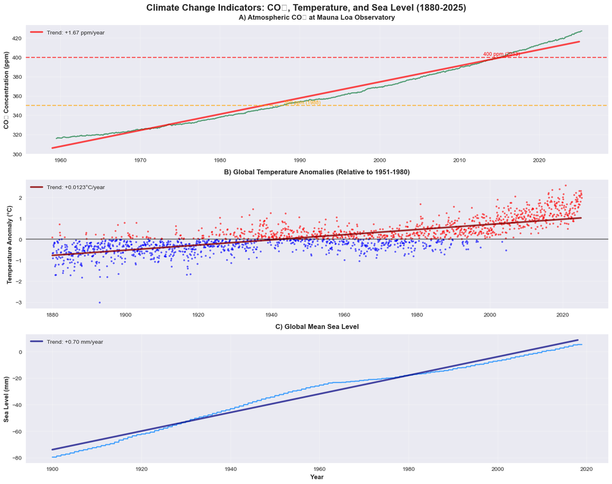

```python
fig, axes = plt.subplots(3, 1, figsize=(15, 12))
fig.suptitle('Climate Change Indicators: CO₂, Temperature, and Sea Level (1880-2025)', fontsize=16, fontweight='bold', y=0.98)

# CO₂ Plot
ax1 = axes[0]
co2_data = climate_df.dropna(subset=['co2_ppm'])
ax1.plot(co2_data['date'], co2_data['co2_ppm'], color='#2E8B57', linewidth=2, alpha=0.8)
if co2_trend:
    # Add trend line
    trend_years = np.arange(co2_trend['start_year'], co2_trend['end_year'] + 1)
    trend_values = co2_trend['intercept'] + co2_trend['slope'] * (trend_years - co2_trend['start_year'])
    trend_dates = pd.to_datetime([f'{year}-01-01' for year in trend_years])
    ax1.plot(trend_dates, trend_values, color='red', linewidth=3, alpha=0.7,
             label=f'Trend: +{co2_trend["slope"]:.2f} ppm/year')

ax1.set_ylabel('CO₂ Concentration (ppm)', fontweight='bold')
ax1.set_title('A) Atmospheric CO₂ at Mauna Loa Observatory', fontweight='bold', pad=10)
ax1.grid(True, alpha=0.3)
ax1.legend()

# Add milestone annotations
ax1.axhline(y=350, color='orange', linestyle='--', alpha=0.7)
ax1.text(pd.to_datetime('1988-01-01'), 352, '350 ppm (1988)', fontsize=9, color='orange')
ax1.axhline(y=400, color='red', linestyle='--', alpha=0.7)
ax1.text(pd.to_datetime('2013-01-01'), 402, '400 ppm (2013)', fontsize=9, color='red')

# Temperature Plot
ax2 = axes[1]
temp_data = climate_df.dropna(subset=['temp_anomaly_C'])
# Create a color gradient based on values
colors = ['blue' if x < 0 else 'red' for x in temp_data['temp_anomaly_C']]
ax2.scatter(temp_data['date'], temp_data['temp_anomaly_C'], c=colors, alpha=0.6, s=8)

if temp_trend:
    # Add trend line
    trend_years = np.arange(temp_trend['start_year'], temp_trend['end_year'] + 1)
    trend_values = temp_trend['intercept'] + temp_trend['slope'] * (trend_years - temp_trend['start_year'])
    trend_dates = pd.to_datetime([f'{year}-01-01' for year in trend_years])
    ax2.plot(trend_dates, trend_values, color='darkred', linewidth=3, alpha=0.8,
             label=f'Trend: +{temp_trend["slope"]:.4f}°C/year')

ax2.axhline(y=0, color='black', linestyle='-', alpha=0.5)
ax2.set_ylabel('Temperature Anomaly (°C)', fontweight='bold')
ax2.set_title('B) Global Temperature Anomalies (Relative to 1951-1980)', fontweight='bold', pad=10)
ax2.grid(True, alpha=0.3)
ax2.legend()

# Sea Level Plot
ax3 = axes[2]
sealevel_data = climate_df.dropna(subset=['sea_level_mm'])
if len(sealevel_data) > 0:
    ax3.plot(sealevel_data['date'], sealevel_data['sea_level_mm'], color='#1E90FF', linewidth=2, alpha=0.8)

    if sealevel_trend:
        # Add trend line
        trend_years = np.arange(sealevel_trend['start_year'], sealevel_trend['end_year'] + 1)
        trend_values = sealevel_trend['intercept'] + sealevel_trend['slope'] * (trend_years - sealevel_trend['start_year'])
        trend_dates = pd.to_datetime([f'{year}-01-01' for year in trend_years])
        ax3.plot(trend_dates, trend_values, color='navy', linewidth=3, alpha=0.7,
                 label=f'Trend: +{sealevel_trend["slope"]:.2f} mm/year')

    ax3.set_ylabel('Sea Level (mm)', fontweight='bold')
    ax3.set_title('C) Global Mean Sea Level', fontweight='bold', pad=10)
    ax3.grid(True, alpha=0.3)
    ax3.legend()
else:
    ax3.text(0.5, 0.5, 'Sea Level Data Not Available', transform=ax3.transAxes,
             ha='center', va='center', fontsize=12)
    ax3.set_title('C) Global Mean Sea Level', fontweight='bold', pad=10)

ax3.set_xlabel('Year', fontweight='bold')

plt.tight_layout()
plt.show()
```

### VISUALIZATION 2: Correlation Analysis

- **Panel A**: Correlation heatmap showing relationships between all variables
- **Panel B**: CO₂ vs Temperature scatter plot colored by decade
- **Panel C**: Time-lagged correlation analysis showing if CO₂ leads temperature
- **Panel D**: CO₂ acceleration analysis over time

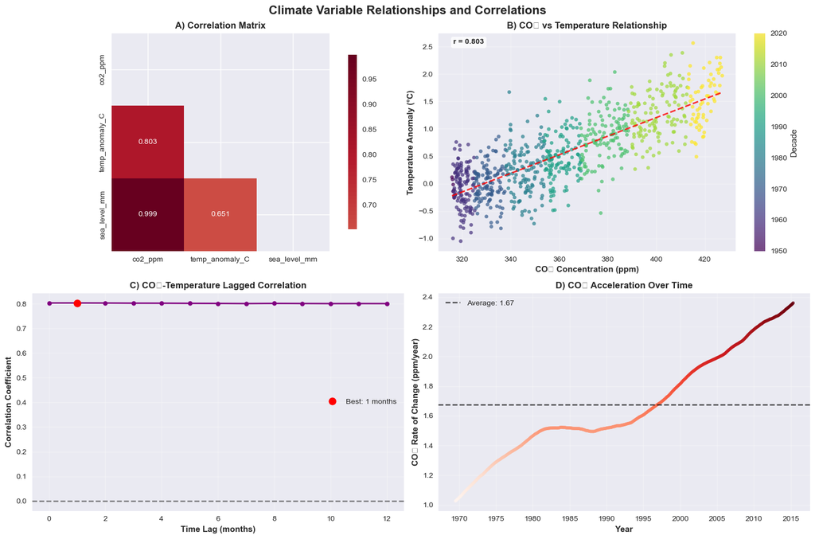

```python
fig, axes = plt.subplots(2, 2, figsize=(15, 10))
fig.suptitle('Climate Variable Relationships and Correlations', fontsize=16, fontweight='bold')

# Correlation Heatmap
ax1 = axes[0, 0]
if correlation_matrix is not None:
    mask = np.triu(np.ones_like(correlation_matrix, dtype=bool))
    sns.heatmap(correlation_matrix, mask=mask, annot=True, cmap='RdBu_r', center=0, square=True, ax=ax1, cbar_kws={"shrink": .8}, fmt='.3f')
ax1.set_title('A) Correlation Matrix', fontweight='bold')

# CO₂ vs Temperature Scatter
ax2 = axes[0, 1]
overlap_data = climate_df.dropna(subset=['co2_ppm', 'temp_anomaly_C'])
if len(overlap_data) > 0:
    # Color by decade
    overlap_data = overlap_data.copy()
    overlap_data['decade'] = (overlap_data['date'].dt.year // 10) * 10

    scatter = ax2.scatter(overlap_data['co2_ppm'], overlap_data['temp_anomaly_C'], c=overlap_data['decade'], cmap='viridis', alpha=0.7, s=20)

    # Add trend line
    z = np.polyfit(overlap_data['co2_ppm'], overlap_data['temp_anomaly_C'], 1)
    p = np.poly1d(z)
    ax2.plot(overlap_data['co2_ppm'], p(overlap_data['co2_ppm']), "r--", alpha=0.8, linewidth=2)

    correlation_coef = overlap_data['co2_ppm'].corr(overlap_data['temp_anomaly_C'])
    ax2.text(0.05, 0.95, f'r = {correlation_coef:.3f}', transform=ax2.transAxes, bbox=dict(boxstyle="round", facecolor='white', alpha=0.8), fontweight='bold')

    plt.colorbar(scatter, ax=ax2, label='Decade')

ax2.set_xlabel('CO₂ Concentration (ppm)', fontweight='bold')
ax2.set_ylabel('Temperature Anomaly (°C)', fontweight='bold')
ax2.set_title('B) CO₂ vs Temperature Relationship', fontweight='bold')
ax2.grid(True, alpha=0.3)

# Time-lagged correlation plot
ax3 = axes[1, 0]
if co2_temp_lags:
    lags = list(co2_temp_lags.keys())
    correlations = list(co2_temp_lags.values())

    ax3.plot(lags, correlations, 'o-', color='purple', linewidth=2, markersize=6)
    ax3.axhline(y=0, color='black', linestyle='--', alpha=0.5)

    # Highlight best correlation
    best_lag, best_corr = max(co2_temp_lags.items(), key=lambda x: abs(x[1]))
    ax3.plot(best_lag, best_corr, 'ro', markersize=10, label=f'Best: {best_lag} months')

    ax3.set_xlabel('Time Lag (months)', fontweight='bold')
    ax3.set_ylabel('Correlation Coefficient', fontweight='bold')
    ax3.set_title('C) CO₂-Temperature Lagged Correlation', fontweight='bold')
    ax3.grid(True, alpha=0.3)
    ax3.legend()

# Acceleration analysis visualization
ax4 = axes[1, 1]
if co2_acceleration:
    dates = co2_acceleration['dates']
    slopes = co2_acceleration['slopes']

    # Create color map based on acceleration
    norm = plt.Normalize(vmin=np.min(slopes), vmax=np.max(slopes))
    colors = plt.cm.Reds(norm(slopes))

    ax4.scatter(dates, slopes, c=colors, alpha=0.7, s=15)
    ax4.axhline(y=np.mean(slopes), color='black', linestyle='--', alpha=0.7, label=f'Average: {np.mean(slopes):.2f}')

    ax4.set_xlabel('Year', fontweight='bold')
    ax4.set_ylabel('CO₂ Rate of Change (ppm/year)', fontweight='bold')
    ax4.set_title('D) CO₂ Acceleration Over Time', fontweight='bold')
    ax4.grid(True, alpha=0.3)
    ax4.legend()

plt.tight_layout()
plt.show()
```

### VISUALIZATION 3: Predictive Models and Projections

- **Panel A**: Model performance (actual vs predicted scatter plot)
- **Panel B**: Time series showing model predictions vs reality
- **Panel C**: Feature importance showing which variables matter most
- **Panel D**: Future projections with three scenarios (current trend, high emissions, low emissions)

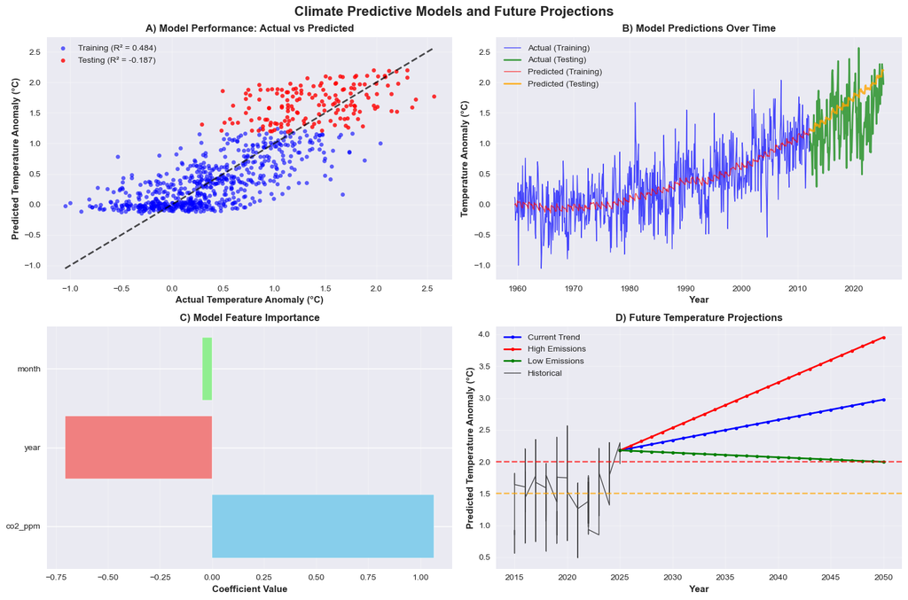

```python
if temp_model:
    fig, axes = plt.subplots(2, 2, figsize=(15, 10))
    fig.suptitle('Climate Predictive Models and Future Projections', fontsize=16, fontweight='bold')

    # Model performance visualization
    ax1 = axes[0, 0]

    # Get model data for visualization
    model_data = climate_df[['date', 'temp_anomaly_C', 'co2_ppm']].dropna()
    model_data['year'] = model_data['date'].dt.year
    model_data['month'] = model_data['date'].dt.month

    # Split for visualization
    split_idx = int(len(model_data) * 0.8)
    train_data = model_data[:split_idx]
    test_data = model_data[split_idx:]

    # Make predictions for visualization
    X_train = train_data[['co2_ppm', 'year', 'month']]
    X_test = test_data[['co2_ppm', 'year', 'month']]

    X_train_scaled = temp_model['scaler'].transform(X_train)
    X_test_scaled = temp_model['scaler'].transform(X_test)

    train_pred = temp_model['model'].predict(X_train_scaled)
    test_pred = temp_model['model'].predict(X_test_scaled)

    # Plot actual vs predicted
    ax1.scatter(train_data['temp_anomaly_C'], train_pred, alpha=0.6, color='blue', label=f'Training (R² = {temp_model["train_r2"]:.3f})', s=20)
    ax1.scatter(test_data['temp_anomaly_C'], test_pred, alpha=0.8, color='red', label=f'Testing (R² = {temp_model["test_r2"]:.3f})', s=20)

    # Perfect prediction line
    min_val = min(model_data['temp_anomaly_C'].min(), min(train_pred.min(), test_pred.min()))
    max_val = max(model_data['temp_anomaly_C'].max(), max(train_pred.max(), test_pred.max()))
    ax1.plot([min_val, max_val], [min_val, max_val], 'k--', alpha=0.7, linewidth=2)

    ax1.set_xlabel('Actual Temperature Anomaly (°C)', fontweight='bold')
    ax1.set_ylabel('Predicted Temperature Anomaly (°C)', fontweight='bold')
    ax1.set_title('A) Model Performance: Actual vs Predicted', fontweight='bold')
    ax1.legend()
    ax1.grid(True, alpha=0.3)

    # Time series of predictions
    ax2 = axes[0, 1]
    ax2.plot(train_data['date'], train_data['temp_anomaly_C'], color='blue', alpha=0.7, linewidth=1, label='Actual (Training)')
    ax2.plot(test_data['date'], test_data['temp_anomaly_C'], color='green', alpha=0.7, linewidth=2, label='Actual (Testing)')
    ax2.plot(train_data['date'], train_pred, color='red', alpha=0.7, linewidth=1, label='Predicted (Training)')
    ax2.plot(test_data['date'], test_pred, color='orange', alpha=0.8, linewidth=2, label='Predicted (Testing)')

    ax2.set_xlabel('Year', fontweight='bold')
    ax2.set_ylabel('Temperature Anomaly (°C)', fontweight='bold')
    ax2.set_title('B) Model Predictions Over Time', fontweight='bold')
    ax2.legend()
    ax2.grid(True, alpha=0.3)

    # Feature importance
    ax3 = axes[1, 0]
    feature_names = list(temp_model['feature_importance'].keys())
    importances = list(temp_model['feature_importance'].values())

    bars = ax3.barh(feature_names, importances, color=['skyblue', 'lightcoral', 'lightgreen'])
    ax3.set_xlabel('Coefficient Value', fontweight='bold')
    ax3.set_title('C) Model Feature Importance', fontweight='bold')
    ax3.grid(True, alpha=0.3, axis='x')

    # Future projections
    ax4 = axes[1, 1]

    # Create future scenarios
    current_co2 = climate_df.dropna(subset=['co2_ppm'])['co2_ppm'].iloc[-1]
    future_years = np.arange(2025, 2051)

    # Scenario 1: Current trend continues
    co2_trend_rate = co2_trend['slope'] if co2_trend else 2.5
    future_co2_trend = current_co2 + co2_trend_rate * (future_years - 2025)

    # Scenario 2: Accelerated emissions
    future_co2_high = current_co2 + (co2_trend_rate * 1.5) * (future_years - 2025)

    # Scenario 3: Reduced emissions
    future_co2_low = current_co2 + (co2_trend_rate * 0.5) * (future_years - 2025)

    # Make predictions for each scenario
    scenarios = {
        'Current Trend': future_co2_trend,
        'High Emissions': future_co2_high,
        'Low Emissions': future_co2_low
    }

    colors = ['blue', 'red', 'green']

    for i, (scenario, co2_values) in enumerate(scenarios.items()):
        future_data = pd.DataFrame({
            'co2_ppm': co2_values,
            'year': future_years,
            'month': 6  # Mid-year
        })

        future_scaled = temp_model['scaler'].transform(future_data)
        future_temp_pred = temp_model['model'].predict(future_scaled)

        ax4.plot(future_years, future_temp_pred, color=colors[i], linewidth=2,
                 label=f'{scenario}', marker='o', markersize=4)

    # Add historical data for context
    recent_data = climate_df.dropna(subset=['temp_anomaly_C']).tail(120)  # Last 10 years
    ax4.plot(recent_data['date'].dt.year, recent_data['temp_anomaly_C'],
             color='black', alpha=0.7, linewidth=1, label='Historical')

    ax4.set_xlabel('Year', fontweight='bold')
    ax4.set_ylabel('Predicted Temperature Anomaly (°C)', fontweight='bold')
    ax4.set_title('D) Future Temperature Projections', fontweight='bold')
    ax4.legend()
    ax4.grid(True, alpha=0.3)

    # Add climate targets
    ax4.axhline(y=1.5, color='orange', linestyle='--', alpha=0.7, label='1.5°C Target')
    ax4.axhline(y=2.0, color='red', linestyle='--', alpha=0.7, label='2°C Target')

    plt.tight_layout()
    plt.show()
```

### VISUALIZATION 4: Comprehensive Dashboard Summary

- Large multi-axis time series showing all variables together
- Key statistics boxes with current rates of change
- Recent trends focus (2015-2025)
- Model performance summary
- Professional layout suitable for presentations

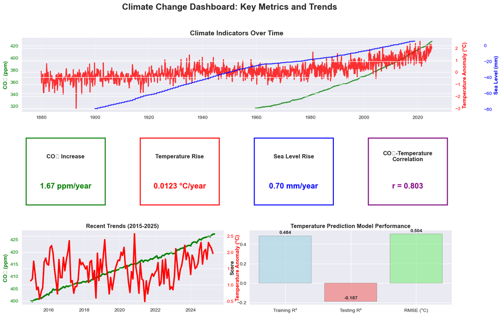

```python
fig = plt.figure(figsize=(16, 10))
gs = fig.add_gridspec(3, 4, hspace=0.3, wspace=0.3)

fig.suptitle('Climate Change Dashboard: Key Metrics and Trends', fontsize=18, fontweight='bold', y=0.98)

# Large time series plot
ax_main = fig.add_subplot(gs[0, :])
ax_main2 = ax_main.twinx()
ax_main3 = ax_main.twinx()
ax_main3.spines['right'].set_position(('outward', 60))

# Plot CO₂
co2_data = climate_df.dropna(subset=['co2_ppm'])
line1 = ax_main.plot(co2_data['date'], co2_data['co2_ppm'], color='green', linewidth=2,
                     label='CO₂ (ppm)', alpha=0.8)
ax_main.set_ylabel('CO₂ (ppm)', color='green', fontweight='bold')
ax_main.tick_params(axis='y', labelcolor='green')

# Plot Temperature
temp_data = climate_df.dropna(subset=['temp_anomaly_C'])
line2 = ax_main2.plot(temp_data['date'], temp_data['temp_anomaly_C'], color='red', linewidth=2,
                      label='Temperature Anomaly (°C)', alpha=0.8)
ax_main2.set_ylabel('Temperature Anomaly (°C)', color='red', fontweight='bold')
ax_main2.tick_params(axis='y', labelcolor='red')

# Plot Sea Level (if available)
sealevel_data = climate_df.dropna(subset=['sea_level_mm'])
if len(sealevel_data) > 0:
    line3 = ax_main3.plot(sealevel_data['date'], sealevel_data['sea_level_mm'], color='blue',
                          linewidth=2, label='Sea Level (mm)', alpha=0.8)
    ax_main3.set_ylabel('Sea Level (mm)', color='blue', fontweight='bold')
    ax_main3.tick_params(axis='y', labelcolor='blue')

ax_main.set_title('Climate Indicators Over Time', fontweight='bold', fontsize=14)
ax_main.grid(True, alpha=0.3)

# Key statistics boxes
stats_data = [
    ('CO₂ Increase', f'{co2_trend["slope"]:.2f} ppm/year' if co2_trend else 'N/A', 'green'),
    ('Temperature Rise', f'{temp_trend["slope"]:.4f} °C/year' if temp_trend else 'N/A', 'red'),
    ('Sea Level Rise', f'{sealevel_trend["slope"]:.2f} mm/year' if sealevel_trend else 'N/A', 'blue')
]

for i, (title, value, color) in enumerate(stats_data):
    ax_stat = fig.add_subplot(gs[1, i])
    ax_stat.text(0.5, 0.7, title, ha='center', va='center', fontsize=12, fontweight='bold',
                 transform=ax_stat.transAxes)
    ax_stat.text(0.5, 0.3, value, ha='center', va='center', fontsize=16, fontweight='bold',
                 color=color, transform=ax_stat.transAxes)
    ax_stat.set_xlim(0, 1)
    ax_stat.set_ylim(0, 1)
    ax_stat.axis('off')

    # Add border
    rect = plt.Rectangle((0.05, 0.05), 0.9, 0.9, linewidth=2, edgecolor=color,
                        facecolor='none', transform=ax_stat.transAxes)
    ax_stat.add_patch(rect)

# Correlation summary
ax_corr = fig.add_subplot(gs[1, 3])
if correlation_matrix is not None:
    co2_temp_corr = correlation_matrix.loc['co2_ppm', 'temp_anomaly_C']
    ax_corr.text(0.5, 0.7, 'CO₂-Temperature\nCorrelation', ha='center', va='center',
                 fontsize=12, fontweight='bold', transform=ax_corr.transAxes)
    ax_corr.text(0.5, 0.3, f'r = {co2_temp_corr:.3f}', ha='center', va='center',
                 fontsize=16, fontweight='bold', color='purple', transform=ax_corr.transAxes)
ax_corr.set_xlim(0, 1)
ax_corr.set_ylim(0, 1)
ax_corr.axis('off')
rect = plt.Rectangle((0.05, 0.05), 0.9, 0.9, linewidth=2, edgecolor='purple',
                    facecolor='none', transform=ax_corr.transAxes)
ax_corr.add_patch(rect)

# Recent trends (last 10 years)
ax_recent = fig.add_subplot(gs[2, :2])
recent_data = climate_df[climate_df['date'] >= '2015-01-01'].copy()

if len(recent_data) > 0:
    ax_recent_temp = ax_recent.twinx()

    # Recent CO₂
    recent_co2 = recent_data.dropna(subset=['co2_ppm'])
    if len(recent_co2) > 0:
        ax_recent.plot(recent_co2['date'], recent_co2['co2_ppm'], color='green',
                      linewidth=3, marker='o', markersize=3, label='CO₂')
        ax_recent.set_ylabel('CO₂ (ppm)', color='green', fontweight='bold')
        ax_recent.tick_params(axis='y', labelcolor='green')

    # Recent Temperature
    recent_temp = recent_data.dropna(subset=['temp_anomaly_C'])
    if len(recent_temp) > 0:
        ax_recent_temp.plot(recent_temp['date'], recent_temp['temp_anomaly_C'], color='red',
                           linewidth=3, marker='s', markersize=3, label='Temperature')
        ax_recent_temp.set_ylabel('Temperature Anomaly (°C)', color='red', fontweight='bold')
        ax_recent_temp.tick_params(axis='y', labelcolor='red')

ax_recent.set_title('Recent Trends (2015-2025)', fontweight='bold')
ax_recent.grid(True, alpha=0.3)

# Model performance summary
ax_model = fig.add_subplot(gs[2, 2:])
if temp_model:
    metrics = ['Training R²', 'Testing R²', 'RMSE (°C)']
    values = [temp_model['train_r2'], temp_model['test_r2'], temp_model['test_rmse']]
    colors = ['lightblue', 'lightcoral', 'lightgreen']

    bars = ax_model.bar(metrics, values, color=colors, alpha=0.7, edgecolor='black')
    ax_model.set_title('Temperature Prediction Model Performance', fontweight='bold')
    ax_model.set_ylabel('Score', fontweight='bold')

    # Add value labels on bars
    for bar, value in zip(bars, values):
        height = bar.get_height()
        ax_model.text(bar.get_x() + bar.get_width()/2., height + 0.01,
                     f'{value:.3f}', ha='center', va='bottom', fontweight='bold')

plt.tight_layout()
plt.show()
```

### 📊 VISUALIZATION SUMMARY:

```python
print("📊 VISUALIZATION SUMMARY:")
print("Created 4 comprehensive visualization sets:")
print("1. Time Series Overview - Shows all three climate indicators with trends")
print("2. Correlation Analysis - Heatmap, scatter plots, and lagged correlations")
print("3. Predictive Models - Model performance and future projections")
print("4. Dashboard Summary - Executive summary with key metrics")
```

```
📊 VISUALIZATION SUMMARY:
Created 4 comprehensive visualization sets:
1. Time Series Overview - Shows all three climate indicators with trends
2. Correlation Analysis - Heatmap, scatter plots, and lagged correlations
3. Predictive Models - Model performance and future projections
4. Dashboard Summary - Executive summary with key metrics
```